# DSCI5340_HW2_Group9

2025-02-13

```r
pacman::p_load(ggplot2, dplyr, lubridate, readr, tsibble, fable, forecast, fastDummies, lmtest, zoo, tidyverse, feasts)
```

## Question:1

```r
passenger <- read.csv("ATL_MAD_Passenger_2010_2023.csv", fileEncoding = "UTF-8")

# Convert date column to Date format
passenger$date <- as.Date(passenger$date, format = "%m/%d/%Y")

# Convert scheduled and total passengers to numeric
passenger$scheduled <- as.numeric(gsub(",", "", passenger$scheduled))
passenger$total <- as.numeric(gsub(",", "", passenger$total))

# Extract year and month
passenger$year <- year(passenger$date)
passenger$month <- month(passenger$date, label = TRUE)

# Distinct Values
passenger %>% summarise(across(everything(), n_distinct))
```

```
##   date us_apt foreign_apt carrier type scheduled total year month
## 1  156      1           1       1    1       154   154   15    12
```

## Question:2

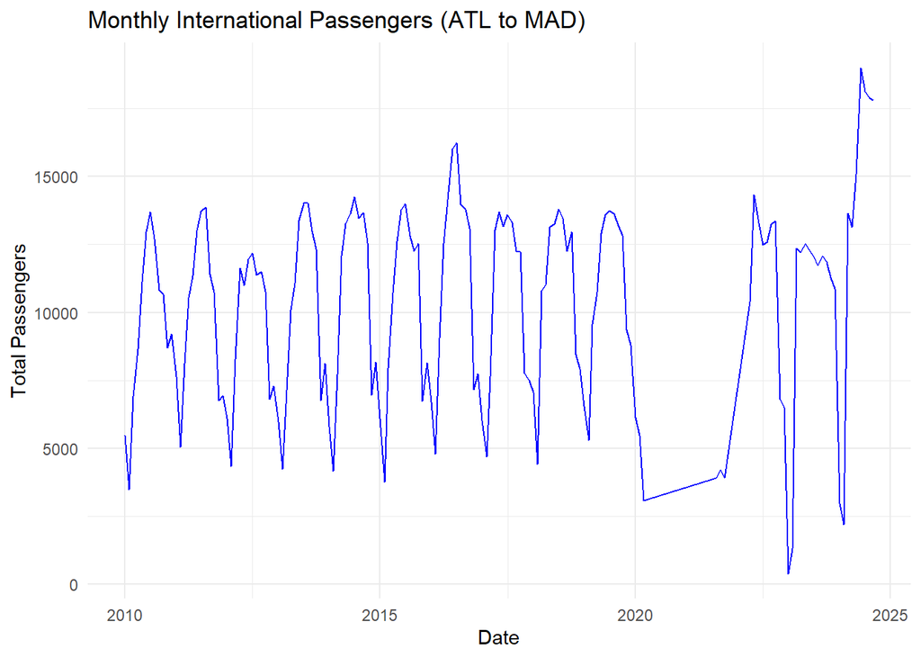

```r
# Check structure of the data
ggplot(passenger, aes(x = date, y = total, group = 1)) +
  geom_line(color = "blue") +
  labs(title = "Monthly International Passengers (ATL to MAD)",
       x = "Date", y = "Total Passengers") +
  theme_minimal()
```

```r
# Aggregate average passengers per month
monthly_avg <- passenger %>%
  group_by(month) %>%
  summarise(avg_passengers = mean(total, na.rm = TRUE))
monthly_avg
```

```
## # A tibble: 12 × 2
##    month avg_passengers
##    <ord>          <dbl>
##  1 Jan            5615.
##  2 Feb            4103.
##  3 Mar            8636.
##  4 Apr           11290.
##  5 May           12808.
##  6 Jun           13791.
##  7 Jul           13992.
##  8 Aug           12763.
##  9 Sep           12247.
## 10 Oct           11528.
## 11 Nov            7802.
## 12 Dec            8101.
```

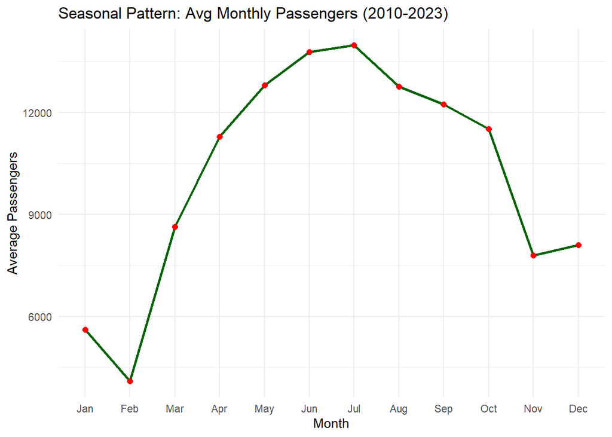

```r
# Plot average passenger trend by month
ggplot(monthly_avg, aes(x = month, y = avg_passengers, group = 1)) +
  geom_line(color = "darkgreen", size = 1) +
  geom_point(color = "red", size = 2) +
  labs(title = "Seasonal Pattern: Avg Monthly Passengers (2010-2023)",
       x = "Month", y = "Average Passengers") +
  theme_minimal()
```

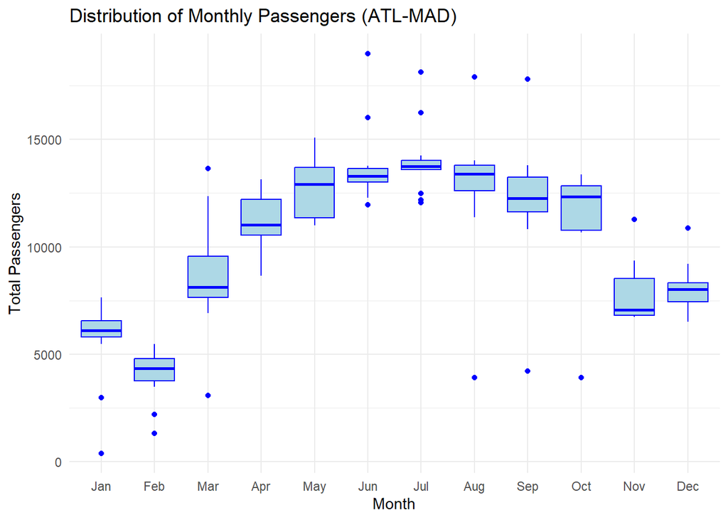

```r
# Passengers by month
ggplot(passenger, aes(x = month, y = total)) +
  geom_boxplot(fill = "lightblue", color = "blue") +
  labs(title = "Distribution of Monthly Passengers (ATL-MAD)",
       x = "Month", y = "Total Passengers") +
  theme_minimal()
```

### Monthly Passengers:

[output not shown]

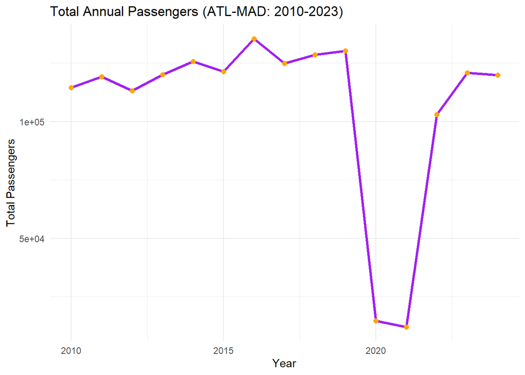

```r
# Yearly passenger totals
yearly_trend <- passenger %>%
  group_by(year) %>%
  summarise(total_passengers = sum(total, na.rm = TRUE))

# Line chart for yearly trends
ggplot(yearly_trend, aes(x = year, y = total_passengers)) +
  geom_line(color = "purple", size = 1.2) +
  geom_point(color = "orange", size = 2) +
  labs(title = "Total Annual Passengers (ATL-MAD: 2010-2023)",
       x = "Year", y = "Total Passengers") +
  theme_minimal()
```

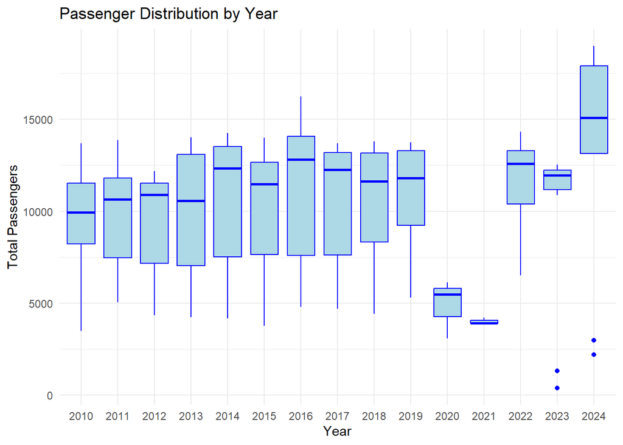

```r
# Passengers by Year
ggplot(passenger, aes(x = factor(year), y = total)) +
  geom_boxplot(fill = "lightblue", color = "blue") +
  labs(title = "Passenger Distribution by Year",
       x = "Year",
       y = "Total Passengers") +
  theme_minimal()
```

### Yearly passenger totals

[output not shown]

## Question:3

```r
passenger$month <- as.numeric(format(passenger$date, "%m"))
passenger$year <- as.numeric(format(passenger$date, "%Y"))

# Log Transform Total Passengers (address heteroscedasticity)
passenger$log_total <- log(passenger$total)

passenger <- passenger %>%
  mutate(lag_log_total = lag(log_total, 1))

# Create a time trend variable (number of months since the beginning of the series)
passenger <- passenger %>% slice(3:n())
passenger$time_trend <- 1:nrow(passenger)

# Create dummy variables for months
passenger <- passenger %>%
  mutate(month_factor = factor(month)) %>%  # Create a factor variable for month
  dummy_cols(select_columns = "month_factor", remove_first_dummy = TRUE)  # Create dummies

# Run the regression with lagged variables
model_lagged <- lm(log_total ~  month_factor_3 + month_factor_4 + month_factor_5 + month_factor_6 + month_factor_7 +
              month_factor_8 + month_factor_9 + month_factor_10 + month_factor_11 +
              month_factor_12 + lag_log_total, data = passenger)

summary(model_lagged)
```

```
##
## Call:
## lm(formula = log_total ~ month_factor_3 + month_factor_4 + month_factor_5 +
##     month_factor_6 + month_factor_7 + month_factor_8 + month_factor_9 +
##     month_factor_10 + month_factor_11 + month_factor_12 + lag_log_total,
##     data = passenger)
##
## Residuals:
##      Min       1Q   Median       3Q      Max
## -2.39745 -0.06549  0.00773  0.07922  0.93164
##
## Coefficients:
##                 Estimate Std. Error t value Pr(>|t|)
## (Intercept)      4.14035    0.60172   6.881 1.76e-10 ***
## month_factor_3   0.87042    0.10512   8.280 8.22e-14 ***
## month_factor_4   0.81119    0.10217   7.939 5.60e-13 ***
## month_factor_5   0.79544    0.10809   7.359 1.36e-11 ***
## month_factor_6   0.80606    0.11168   7.218 2.93e-11 ***
## month_factor_7   0.78679    0.11396   6.904 1.56e-10 ***
## month_factor_8   0.70366    0.10897   6.457 1.58e-09 ***
## month_factor_9   0.67647    0.10837   6.242 4.70e-09 ***
## month_factor_10  0.65015    0.10859   5.987 1.66e-08 ***
## month_factor_11  0.25412    0.11264   2.256   0.0256 *
## month_factor_12  0.51646    0.10383   4.974 1.87e-06 ***
## lag_log_total    0.48435    0.06859   7.061 6.76e-11 ***
## ---
## Signif. codes:  0 '***' 0.001 '**' 0.01 '*' 0.05 '.' 0.1 ' ' 1
##
## Residual standard error: 0.2906 on 142 degrees of freedom
## Multiple R-squared:  0.6951, Adjusted R-squared:  0.6715
## F-statistic: 29.43 on 11 and 142 DF,  p-value: < 2.2e-16
```

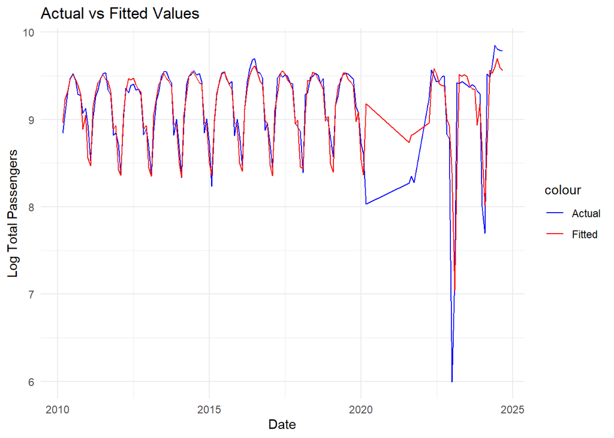

```r
# Create a data frame with original and fitted values
fitted_vs_actual <- data.frame(
  Date = passenger$date,
  Actual = passenger$log_total,  # Original log-transformed total passengers
  Fitted = model_lagged$fitted.values
)

# Optional: Create a visualization
ggplot(fitted_vs_actual, aes(x = Date)) +
  geom_line(aes(y = Actual, color = "Actual")) +
  geom_line(aes(y = Fitted, color = "Fitted")) +
  labs(title = "Actual vs Fitted Values", x = "Date", y = "Log Total Passengers") +
  scale_color_manual(values = c("Actual" = "blue", "Fitted" = "red")) +
  theme_minimal()
```

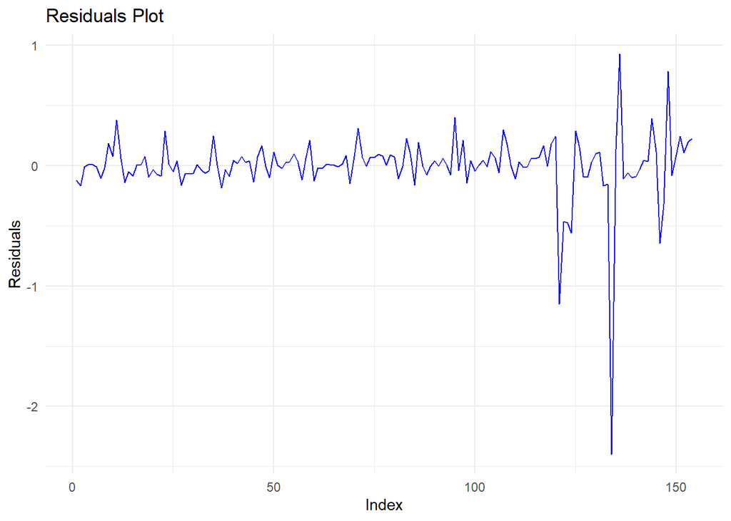

```r
# Convert residuals to a data frame
residuals_df <- data.frame(Index = 1:length(model_lagged$residuals), Residuals = model_lagged$residuals)

# Create the residual plot using ggplot2
ggplot(residuals_df, aes(x = Index, y = Residuals)) +
  geom_line(color = "blue") +
  labs(title = "Residuals Plot", x = "Index", y = "Residuals") +
  theme_minimal()
```

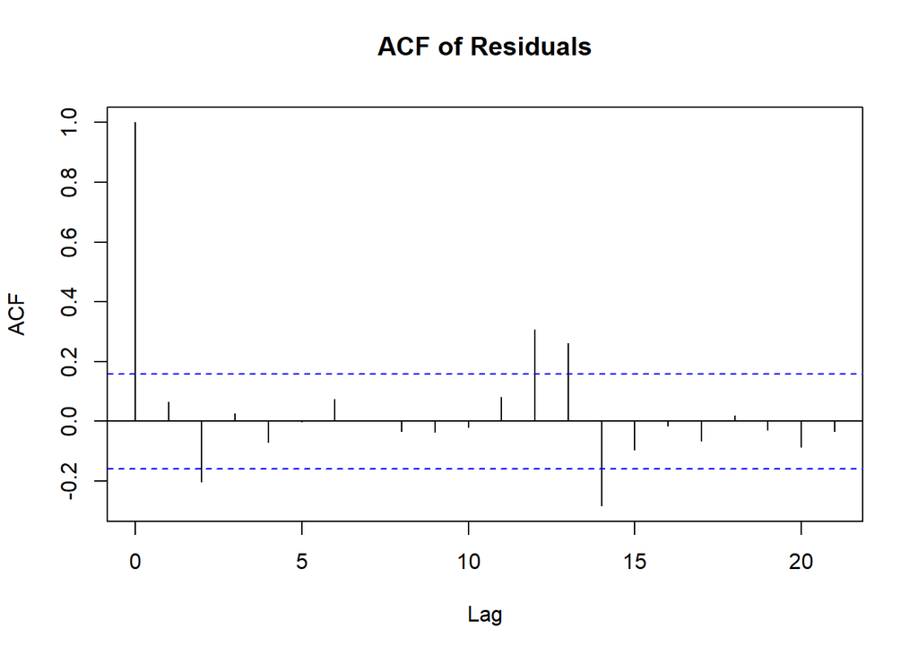

```r
acf(model_lagged$residuals, main = "ACF of Residuals")  # Checks for autocorrelation
```

```r
Box.test(model_lagged$residuals, lag = 10, type = "Ljung-Box")
```

```
##
##  Box-Ljung test
##
## data:  model_lagged$residuals
## X-squared = 9.3003, df = 10, p-value = 0.5039
```

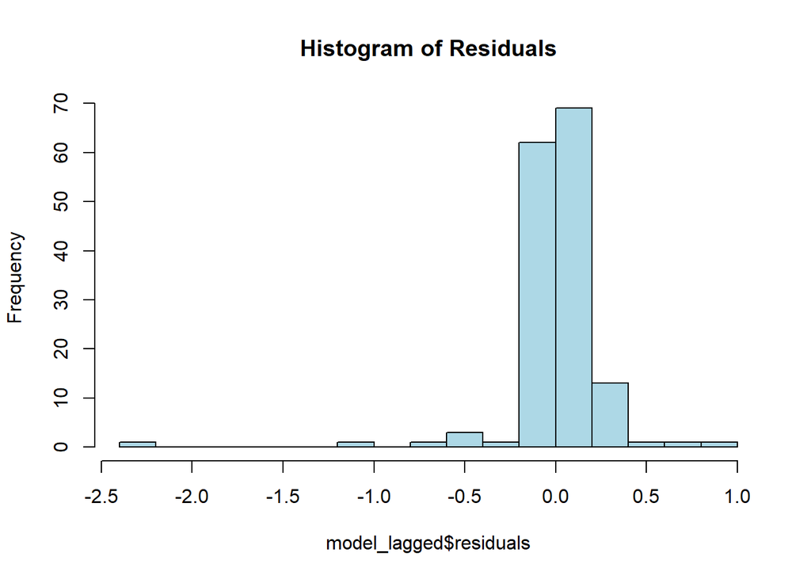

```r
hist(model_lagged$residuals, breaks = 20, col = "lightblue", main = "Histogram of Residuals")
```

## Why we chose this model:

### Past Models:

Initially, we experimented with models that included a time trend, monthly dummies, log-transformed passenger counts, and a quadratic time trend (time_trend^2). However, these models showed strong autocorrelation, and the Ljung-Box test results indicated they did not fully capture time-dependent patterns.

**Here are the models we tested:**

model1 <- tslm(passengerts ~ trend + season)

model2 <- tslm(passengerts ~ trend + season + passenger$lag_total)

model3 <- lm(total ~ time_trend + month_factor_2 + month_factor_3 + month_factor_4 + month_factor_5 + month_factor_6 + month_factor_7 + month_factor_8 + month_factor_9 + month_factor_10 + month_factor_11 + month_factor_12, data = passenger_data)

model4 <- lm(total ~ time_trend + time_trend_squared + month_factor_2 + month_factor_3 + month_factor_4 + month_factor_5 + month_factor_6 + month_factor_7 + month_factor_8 + month_factor_9 + month_factor_10 + month_factor_11 + month_factor_12, data = passenger_data)

model5 <- lm(log(total) ~ time_trend + month_factor_2 + month_factor_3 + month_factor_4 + month_factor_5 + month_factor_6 + month_factor_7 + month_factor_8 + month_factor_9 + month_factor_10 + month_factor_11 + month_factor_12, data = passenger_data)

model6 <- lm(log_total ~ time_trend + month_factor_2 + month_factor_3 + month_factor_4 + month_factor_5 + month_factor_6 + month_factor_7 + month_factor_8 + month_factor_9 + month_factor_10 + month_factor_11 + month_factor_12 + lag_log_total, data = passenger)

While these models helped understand trends and seasonality, they still suffered from autocorrelation. By incorporating lagged log values, we addressed this issue and improved model performance significantly.

## Question:4

```r
# Create a data frame for the next 12 months
forecast_data <- data.frame(date = seq(tail(passenger$date, 1) + months(1), by = "month", length.out = 12))

# Extract month for dummy variables and create time trend
forecast_data$month <- as.numeric(format(forecast_data$date, "%m"))
forecast_data$year <- as.numeric(format(forecast_data$date, "%Y"))
forecast_data$time_trend <- (nrow(passenger) + 1):(nrow(passenger) + 12)

# Create month factor and dummy variables
forecast_data <- forecast_data %>%
  mutate(month_factor = factor(month)) %>%
  dummy_cols(select_columns = "month_factor", remove_first_dummy = TRUE)

# Impute lag using the last actual value
forecast_data$lag_log_total <- tail(passenger$log_total, 1)

# Predict log_total using the regression model
forecast_data$total_forecast <- exp(predict(model_lagged, newdata = forecast_data))

# Print only date and total_forecast
forecast_data %>% select(date, total_forecast) %>% print()
```

```
##          date total_forecast
## 1  2024-10-01      13775.975
## 2  2024-11-01       9271.030
## 3  2024-12-01      12052.120
## 4  2025-01-01       7190.608
## 5  2025-02-01       7190.608
## 6  2025-03-01      17170.578
## 7  2025-04-01      16183.074
## 8  2025-05-01      15930.225
## 9  2025-06-01      16100.273
## 10 2025-07-01      15793.025
## 11 2025-08-01      14533.224
## 12 2025-09-01      14143.380
```

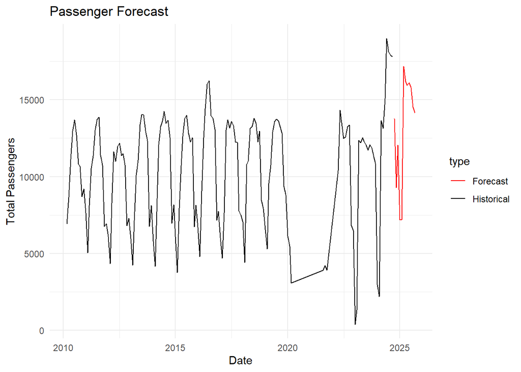

```r
# Combine historical data and forecast data for plotting. Ensure the forecast period dates are in the correct format
combined_data <- bind_rows(data.frame(date = passenger$date, total = passenger$total, type = "Historical"),
                           data.frame(date = forecast_data$date, total = forecast_data$total_forecast, type = "Forecast"))

# Create the plot
ggplot(combined_data, aes(x = date, y = total, color = type)) +
  geom_line() +
  labs(title = "Passenger Forecast",
       x = "Date",
       y = "Total Passengers") +
  scale_color_manual(values = c("Historical" = "black", "Forecast" = "red")) +
  theme_minimal()
```

#————————————ARIMA————————————-

```r
# Convert to Time Series
passengerts <- passenger|>
  mutate(date = yearmonth(date)) |>
  as_tsibble(index = date) |>
  fill_gaps() |>
  mutate(total = if_else(is.na(total), 0, total))

# Fit ARIMA model
model_arima <- passengerts |>
  model(
    arima_reg = ARIMA(total ~ trend() + season())
  )
report(model_arima)
```

```
## Series: total
## Model: LM w/ ARIMA(1,0,2)(0,0,1)[12] errors
##
## Coefficients:
##          ar1     ma1      ma2    sma1  trend()  season()year2  season()year3
##       0.9405  0.0043  -0.1754  0.3295  45.4207     -1275.8823      2766.0085
## s.e.  0.0299  0.0817   0.0836  0.0966  20.5106       580.7367       794.6732
##       season()year4  season()year5  season()year6  season()year7  season()year8
##           4996.1935      6322.9054       7214.171      7328.6669        7042.43
## s.e.       871.7538       923.7347        954.959       966.1135         958.68
##       season()year9  season()year10  season()year11  season()year12
##            6497.540       6136.3014       2173.3871       2321.1316
## s.e.        932.438        880.7453        801.3473        583.6432
##
## sigma^2 estimated as 2976086:  log likelihood=-1545.99
## AIC=3125.99   AICc=3129.88   BIC=3179.79
```

```r
# Forecast next 12 months
forecast_arima <- forecast(model_arima, h = 12)

# Print forecasted values
print(forecast_arima)
```

```
## # A fable: 12 x 4 [1M]
## # Key:     .model [1]
##    .model        date
##    <chr>        <mth>
##  1 arima_reg 2024 Oct
##  2 arima_reg 2024 Nov
##  3 arima_reg 2024 Dec
##  4 arima_reg 2025 Jan
##  5 arima_reg 2025 Feb
##  6 arima_reg 2025 Mar
##  7 arima_reg 2025 Apr
##  8 arima_reg 2025 May
##  9 arima_reg 2025 Jun
## 10 arima_reg 2025 Jul
## 11 arima_reg 2025 Aug
## 12 arima_reg 2025 Sep
## # ℹ 2 more variables: total <dist>, .mean <dbl>
```

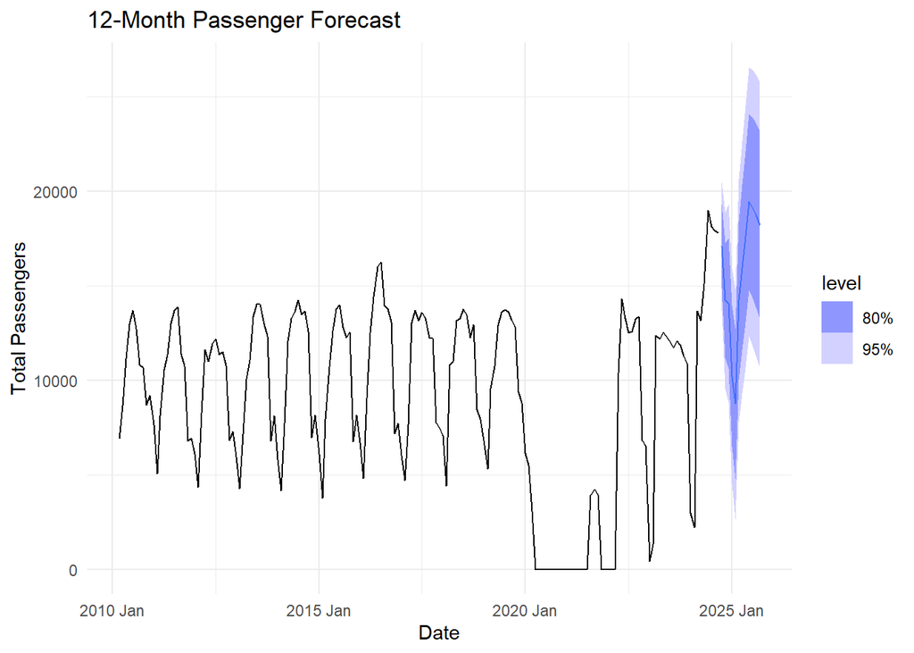

```r
# Plot the forecast
autoplot(forecast_arima,passengerts) +
  ggtitle("12-Month Passenger Forecast") +
  xlab("Date") +
  ylab("Total Passengers") +
  theme_minimal()
```

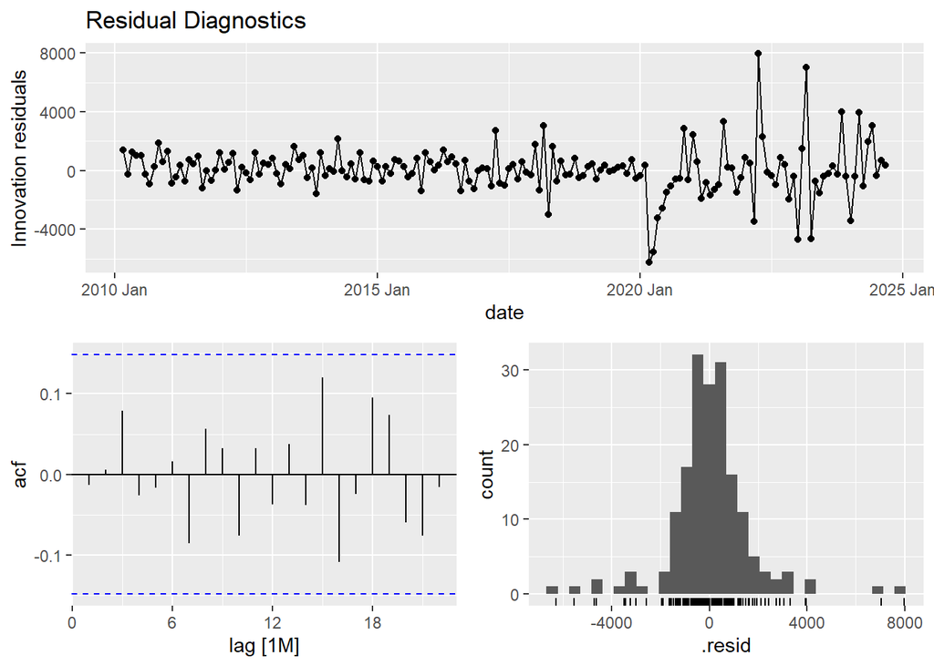

```r
# Check residual patterns
model_arima |>
  gg_tsresiduals() +
  labs(title = "Residual Diagnostics")
```

```r
# Ljung-Box Test for ARIMA Residuals
model_arima |>
  augment() |>
  features(.resid, ljung_box, lag = 12)
```

```
## # A tibble: 1 × 3
##   .model    lb_stat lb_pvalue
##   <chr>       <dbl>     <dbl>
## 1 arima_reg    5.08     0.955
```

We also selected an ARIMA model for our 12-month passenger forecast because it’s well-suited to capturing underlying trends and seasonal patterns in time series data, particularly with a limited dataset of 156 points. This method shines due to its strong and flexible performance in short-term forecasts. Furthermore, the Ljung-Box test yielded a high p-value (0.9554), indicating that the model effectively addressed any significant autocorrelation in the residuals, allowing for reliable inferences and predictions.